# 102.6. Catalog access with LSDB

For the Rubin Science Platform at data.lsst.cloud.  
Data Release: [Data Preview 2](https://dp2.lsst.io/)  
Container Size: Large  
LSST Science Pipelines version: v30.0.10  
Last verified to run: 2026-07-27  
Repository: github.com/lsst/tutorial-notebooks

**Learning objective:** How to access Rubin data in LSDB format.

**LSST data products:** `Object`, `DiaObject`, `DiaSource`, `ForcedSource`, and `ForcedSourceOnDiaObject`

**Packages:** `lsdb`

**Credit:** Originally developed by the Rubin Community Science team with input from Neven Caplar, Tianqing Zhang, and Olivia Lynn. Please consider acknowledging them if this notebook is used for the preparation of journal articles, software releases, or other notebooks.

**Get Support:** Everyone is encouraged to ask questions or raise issues in the [Support Category](https://community.lsst.org/c/support) of the Rubin Community Forum. Rubin staff will respond to all questions posted there.

## 1. Introduction

[LSDB](https://docs.lsdb.io/) is an open-source Python framework that enables fast all-sky cross-matching, bulk application of user-defined functions, and simplified analysis of time-domain (light curve) data. Built on top of [Dask](https://docs.dask.org/), LSDB uses the [HATS](https://hats.readthedocs.io/) (Hierarchical Adaptive Tiling Scheme) data format ([HEALPix](https://healpix.sourceforge.io/documentation.php)-sharded [Parquet](https://parquet.apache.org/docs/)), which provides an efficient, spatially-indexed format for storing catalog data.

LSDB also hosts many other datasets stored in the HATS format beyond the DP2 catalogs shown in this tutorial, but **the DP2 HATS catalogs are only available on the Rubin Science Platform (RSP).** Find the full list of LSDB-hosted datasets at [data.lsdb.io](https://data.lsdb.io/).

> **Note:** This notebook is intended only as a simple tutorial on LSDB DP2 catalogs. For more detailed examples and advanced use cases, see the full set of LSDB tutorials at [LSDB tutorials](https://docs.lsdb.io/en/latest/tutorials.html).

**References:**

- Descriptions of LSDB-formatted Rubin data: https://data.lsdb.io/
- LSDB documentation: [docs.lsdb.io](https://docs.lsdb.io/en/latest/index.html)
- [Working with Rubin Data using LSDB](https://docs.lsdb.io/en/latest/tutorial_toc/toc_rubin.html)
- [LSDB hackathon at the Rubin Community Workshop 2025](https://github.com/lincc-frameworks/RCW_Hackathon_2025_LSDB/tree/main)

**Related tutorials:** The 200-level tutorials on the `Object`, `DiaObject`, `DiaSource`, `ForcedSource`, and `ForcedSourceOnDiaObject` catalogs. The 300-level tutorial on how to access photometric redshifts in LSDB-formatted files.

### 1.1. Import packages

Import the [LSDB package](https://github.com/astronomy-commons/lsdb/) to work with LSDB-formatted files, [`upath`](https://github.com/fsspec/universal_pathlib) for handling local and remote file paths uniformly, and `matplotlib.pyplot` for visualization.

```python
import lsdb
import astropy.units as u
from astropy.coordinates import SkyCoord
from upath import UPath
import matplotlib.pyplot as plt
from lsst.utils.plotting import (get_multiband_plot_colors,
                                 get_multiband_plot_symbols)
```

Define the filter names, colors, and symbols to use when plotting.

```python
filter_colors = get_multiband_plot_colors()
filter_names = filter_colors.keys()
filter_symbols = get_multiband_plot_symbols()
```

Set the base path to the LSDB-formatted DP2 data on the RSP.

```python
base_path = UPath("/rubin/lsdb_data/dp2")
```

## 2. Access the LSDB DP2 catalogs

The LSDB DP2 read-only catalogs available on the Rubin Science Platform at `data.lsst.cloud` are located in the directory `/rubin/lsdb_data`.

Two of them are HATS **collections** (a main catalog packaged together with a margin cache and ID-based index tables):

- `object_collection`: the `Object` table, with the forced photometry nested in an `objectForcedSource` column
- `dia_object_collection`: the `DiaObject` table, with `diaSource` and `diaObjectForcedSource` nested columns

The third is a **standalone catalog**:

- `object_photoz`: the photometric redshift estimates table (see Section 2.3, below)

Note that, unlike DP1 in the Rubin Science Platform, there is no `object_collection_lite` catalog for DP2.

### 2.1. object_collection

This LSDB-formatted catalog is the same as the DP2 `Object` table but with additional columns, `<f>_psfMag` and `<f>_psfMagErr`, which are the corresponding `<f>_psfFlux` columns converted to magnitudes (for each filter, `<f>`, in $ugrizy$).

[Column descriptions for the DP2 tables](https://sdm-schemas.lsst.io/dp2.html#Object).

#### 2.1.1. Load and display the catalog

```python
object_cat = lsdb.open_catalog(base_path / "object_collection")
```

```python
object_cat
```

**lsdb Catalog object_lc:**

| npartitions=8840 | coord_dec | coord_decErr | coord_ra | coord_raErr | g_psfFlux | g_psfFluxErr | g_psfMag | g_psfMagErr | i_psfFlux | i_psfFluxErr | i_psfMag | i_psfMagErr | objectId | patch | r_psfFlux | r_psfFluxErr | r_psfMag | r_psfMagErr | refBand | shape_flag | shape_xx | shape_xy | shape_yy | tract | u_psfFlux | u_psfFluxErr | u_psfMag | u_psfMagErr | y_psfFlux | … |
| --- | --- | --- | --- | --- | --- | --- | --- | --- | --- | --- | --- | --- | --- | --- | --- | --- | --- | --- | --- | --- | --- | --- | --- | --- | --- | --- | --- | --- | --- | --- |
| Order: 8, Pixel: 10240 | double[pyarrow] | float[pyarrow] | double[pyarrow] | float[pyarrow] | float[pyarrow] | float[pyarrow] | float[pyarrow] | float[pyarrow] | float[pyarrow] | float[pyarrow] | float[pyarrow] | float[pyarrow] | int64[pyarrow] | int64[pyarrow] | float[pyarrow] | float[pyarrow] | float[pyarrow] | float[pyarrow] | string[pyarrow] | bool[pyarrow] | float[pyarrow] | float[pyarrow] | float[pyarrow] | int64[pyarrow] | float[pyarrow] | float[pyarrow] | float[pyarrow] | float[pyarrow] | float[pyarrow] | … |
| ... | ... | ... | ... | ... | ... | ... | ... | ... | ... | ... | ... | ... | ... | ... | ... | ... | ... | ... | ... | ... | ... | ... | ... | ... | ... | ... | ... | ... | ... | … |
| Order: 5, Pixel: 12283 | ... | ... | ... | ... | ... | ... | ... | ... | ... | ... | ... | ... | ... | ... | ... | ... | ... | ... | ... | ... | ... | ... | ... | ... | ... | ... | ... | ... | ... | … |
| Order: 5, Pixel: 12284 | ... | ... | ... | ... | ... | ... | ... | ... | ... | ... | ... | ... | ... | ... | ... | ... | ... | ... | ... | ... | ... | ... | ... | ... | ... | ... | ... | ... | ... | … |

37 out of 1261 available columns in the catalog have been loaded lazily, meaning no data has been read, only the catalog schema

This catalog has an estimated size of 1.5 TB

**Lazily loaded catalogs:** note the message under the displayed table above, that all of the columns have been loaded "lazily". This is always the default for LSDB catalogs, and it means that only the metadata is loaded at first. This way, LSDB can plan how tasks will be executed in the future without actually doing any computation.

`Order` is the HEALPix resolution, and `Pixel` is the HEALPix index of the specific sky patch.

Optional: uncomment the following cell and press "tab" to browse the available methods on an LSDB catalog like `object_cat`.

```python
# object_cat.
```

Additionally, a table of catalog methods and descriptions can be viewed on the [Catalog page](https://docs.lsdb.io/en/latest/reference/api/lsdb.catalog.Catalog.html) in the LSDB API Reference.

#### 2.1.2. Show column names

Display the subset of 37 columns that are lazily loaded by default.

```python
object_cat.columns
```

```
Index(['coord_dec', 'coord_decErr', 'coord_ra', 'coord_raErr', 'g_psfFlux',
       'g_psfFluxErr', 'g_psfMag', 'g_psfMagErr', 'i_psfFlux', 'i_psfFluxErr',
       'i_psfMag', 'i_psfMagErr', 'objectId', 'patch', 'r_psfFlux',
       'r_psfFluxErr', 'r_psfMag', 'r_psfMagErr', 'refBand', 'shape_flag',
       'shape_xx', 'shape_xy', 'shape_yy', 'tract', 'u_psfFlux',
       'u_psfFluxErr', 'u_psfMag', 'u_psfMagErr', 'y_psfFlux', 'y_psfFluxErr',
       'y_psfMag', 'y_psfMagErr', 'z_psfFlux', 'z_psfFluxErr', 'z_psfMag',
       'z_psfMagErr', 'objectForcedSource'],
      dtype='object')
```

Optional: uncomment the cell below to display the names of a larger subset of the 1261 columns from the `Object` catalog.

```python
# object_cat.all_columns
```

Search for column names that contain a string, such as `psfMag` (i.e., the columns that contain the PSF fluxes converted to magnitudes).

```python
search_string = 'psfMag'
for col in object_cat.all_columns:
    if search_string in col:
        print(col)
```

```
u_psfMag
u_psfMagErr
g_psfMag
g_psfMagErr
r_psfMag
r_psfMagErr
i_psfMag
i_psfMagErr
z_psfMag
z_psfMagErr
y_psfMag
y_psfMagErr
```

Load only selected columns

```python
use_columns = ['coord_dec', 'coord_decErr', 'coord_ra', 'coord_raErr',
               'g_psfFlux', 'g_psfFluxErr', 'g_psfMag', 'g_psfMagErr']
```

```python
object_cat_selected_columns = lsdb.open_catalog(base_path / "object_collection",
                                                columns=use_columns)
```

```python
object_cat_selected_columns.columns
```

```
Index(['coord_dec', 'coord_decErr', 'coord_ra', 'coord_raErr', 'g_psfFlux',
       'g_psfFluxErr', 'g_psfMag', 'g_psfMagErr'],
      dtype='object')
```

#### 2.1.3. Execute a cone search

Cone searches are supported and defined by a center (`ra`, `dec`), in degrees, and a radius `r`, in arcseconds. Execute a cone search on the object catalog using the coordinates (in degrees) of the Extended Chandra Deep Field South (ECDFS) field, with a radius of 0.1 deg.

```python
ra_ecdfs = 53.16
dec_ecdfs = -28.10
```

```python
object_cat_ecdfs = object_cat.cone_search(ra=ra_ecdfs, dec=dec_ecdfs,
                                          radius_arcsec=0.1 * 3600.0)
```

This table contains only 2 partitions, compared to the 8,840 described in Section 2.1.1, due to the 0.1-degree spatial restriction.

```python
object_cat_ecdfs
```

**lsdb Catalog object_lc:**

| npartitions=2 | coord_dec | coord_decErr | coord_ra | coord_raErr | g_psfFlux | g_psfFluxErr | g_psfMag | g_psfMagErr | i_psfFlux | i_psfFluxErr | i_psfMag | i_psfMagErr | objectId | patch | r_psfFlux | r_psfFluxErr | r_psfMag | r_psfMagErr | refBand | shape_flag | shape_xx | shape_xy | shape_yy | tract | u_psfFlux | u_psfFluxErr | u_psfMag | u_psfMagErr | y_psfFlux | … |
| --- | --- | --- | --- | --- | --- | --- | --- | --- | --- | --- | --- | --- | --- | --- | --- | --- | --- | --- | --- | --- | --- | --- | --- | --- | --- | --- | --- | --- | --- | --- |
| Order: 7, Pixel: 143740 | double[pyarrow] | float[pyarrow] | double[pyarrow] | float[pyarrow] | float[pyarrow] | float[pyarrow] | float[pyarrow] | float[pyarrow] | float[pyarrow] | float[pyarrow] | float[pyarrow] | float[pyarrow] | int64[pyarrow] | int64[pyarrow] | float[pyarrow] | float[pyarrow] | float[pyarrow] | float[pyarrow] | string[pyarrow] | bool[pyarrow] | float[pyarrow] | float[pyarrow] | float[pyarrow] | int64[pyarrow] | float[pyarrow] | float[pyarrow] | float[pyarrow] | float[pyarrow] | float[pyarrow] | … |
| Order: 7, Pixel: 143742 | ... | ... | ... | ... | ... | ... | ... | ... | ... | ... | ... | ... | ... | ... | ... | ... | ... | ... | ... | ... | ... | ... | ... | ... | ... | ... | ... | ... | ... | … |

37 out of 1261 available columns in the catalog have been loaded lazily, meaning no data has been read, only the catalog schema

This catalog has an estimated size of 330.0 MB

```python
object_cat_ecdfs.head(3)
```

|  | coord_dec | coord_decErr | coord_ra | coord_raErr | g_psfFlux | g_psfFluxErr | g_psfMag | g_psfMagErr | i_psfFlux | i_psfFluxErr | i_psfMag | i_psfMagErr | objectId | patch | r_psfFlux | r_psfFluxErr | r_psfMag | r_psfMagErr | refBand | shape_flag | shape_xx | shape_xy | shape_yy | tract | u_psfFlux | u_psfFluxErr | u_psfMag | u_psfMagErr | y_psfFlux | … |
| --- | --- | --- | --- | --- | --- | --- | --- | --- | --- | --- | --- | --- | --- | --- | --- | --- | --- | --- | --- | --- | --- | --- | --- | --- | --- | --- | --- | --- | --- | --- |
| 2528713655233233018 | -28.197422 | 0.000059 | 53.185212 | 0.000060 | 256.604614 | 48.610924 | 25.376839 | 0.208196 | 179.061340 | 51.245422 | 25.767496 | 0.319652 | 755368886328655590 | 4 | 209.812103 | 43.972267 | 25.595423 | 0.230970 | u | False | 6.486713 | 3.180672 | 3.125711 | 5063 | 497.289703 | 149.751480 | 24.658476 | 0.337412 | 834.247314 | … |
| 2528713666530162584 | -28.196704 | 0.000034 | 53.188282 | 0.000050 | 359.658905 | 46.214226 | 25.010273 | 0.140287 | 925.936401 | 73.264442 | 23.983547 | 0.086089 | 755368886328655582 | 4 | 944.091980 | 200.538177 | 23.962463 | 0.234191 | y | True | 12.425080 | -0.936475 | 11.900757 | 5063 | 648.193054 | 150.862839 | 24.370739 | 0.257415 | 6487.844238 | … |
| 2528713666580786025 | -28.196037 |  | 53.188218 |  | 5844.588867 | 58.671440 | 21.983114 | 0.010900 | 6426.307129 | 78.089821 | 21.880096 | 0.013194 | 755368886328655577 | 4 |  |  |  |  | y | True | 40.866325 | 35.522091 | 207.306259 | 5063 | 1456.542236 | 151.620728 | 23.491692 | 0.113432 | 18976.408203 | … |

3 rows x 37 columns

```python
object_cat_ecdfs.columns
```

```
Index(['coord_dec', 'coord_decErr', 'coord_ra', 'coord_raErr', 'g_psfFlux',
       'g_psfFluxErr', 'g_psfMag', 'g_psfMagErr', 'i_psfFlux', 'i_psfFluxErr',
       'i_psfMag', 'i_psfMagErr', 'objectId', 'patch', 'r_psfFlux',
       'r_psfFluxErr', 'r_psfMag', 'r_psfMagErr', 'refBand', 'shape_flag',
       'shape_xx', 'shape_xy', 'shape_yy', 'tract', 'u_psfFlux',
       'u_psfFluxErr', 'u_psfMag', 'u_psfMagErr', 'y_psfFlux', 'y_psfFluxErr',
       'y_psfMag', 'y_psfMagErr', 'z_psfFlux', 'z_psfFluxErr', 'z_psfMag',
       'z_psfMagErr', 'objectForcedSource'],
      dtype='object')
```

Visualize the object distribution in the region.

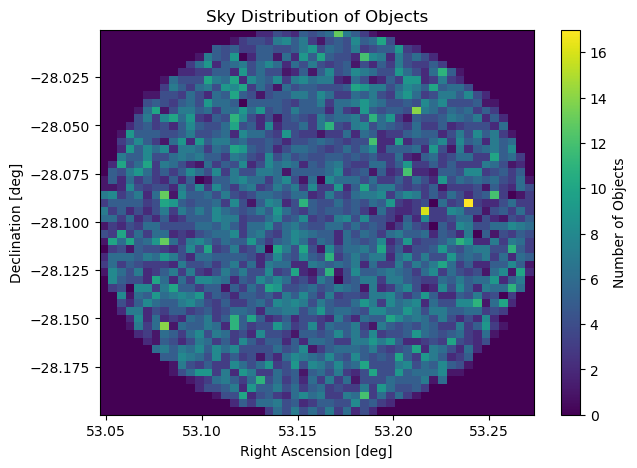

```python
plt.figure(figsize=(7, 5))
plt.hist2d(object_cat_ecdfs['coord_ra'], object_cat_ecdfs['coord_dec'],
           bins=50, cmap='viridis')
plt.colorbar(label="Number of Objects")
plt.xlabel("Right Ascension [deg]")
plt.ylabel("Declination [deg]")
plt.title("Sky Distribution of Objects")
plt.show()
```

> **Figure 1:** A 2-dimensional distribution (heatmap) of the number of objects across the sky, as returned by the cone search centered on the ECDFS field.

#### 2.1.4. Execute a query on column values

It is possible to filter LSDB catalogs using the `.query()` method.  
The query expression is written as a string and follows the same syntax as [Pandas `.query()`](https://pandas.pydata.org/docs/reference/api/pandas.DataFrame.query.html), which supports a subset of Python expressions for filtering DataFrames.

Select only objects with an $r$-band PSF magnitude between 16 and 24 mag.

Apply the query to the cone-search result from Section 2.1.3 rather than to the full catalog: parts of the DP2 footprint have no $r$-band coverage (all-NaN `r_psfMag`), so a `.head()` on a full-catalog query could scan through very many partitions before finding matching rows.

```python
object_cat_mag_range = object_cat_ecdfs.query("r_psfMag > 16 and r_psfMag < 24")
object_cat_mag_range
```

**lsdb Catalog object_lc:**

| npartitions=2 | coord_dec | coord_decErr | coord_ra | coord_raErr | g_psfFlux | g_psfFluxErr | g_psfMag | g_psfMagErr | i_psfFlux | i_psfFluxErr | i_psfMag | i_psfMagErr | objectId | patch | r_psfFlux | r_psfFluxErr | r_psfMag | r_psfMagErr | refBand | shape_flag | shape_xx | shape_xy | shape_yy | tract | u_psfFlux | u_psfFluxErr | u_psfMag | u_psfMagErr | y_psfFlux | … |
| --- | --- | --- | --- | --- | --- | --- | --- | --- | --- | --- | --- | --- | --- | --- | --- | --- | --- | --- | --- | --- | --- | --- | --- | --- | --- | --- | --- | --- | --- | --- |
| Order: 7, Pixel: 143740 | double[pyarrow] | float[pyarrow] | double[pyarrow] | float[pyarrow] | float[pyarrow] | float[pyarrow] | float[pyarrow] | float[pyarrow] | float[pyarrow] | float[pyarrow] | float[pyarrow] | float[pyarrow] | int64[pyarrow] | int64[pyarrow] | float[pyarrow] | float[pyarrow] | float[pyarrow] | float[pyarrow] | string[pyarrow] | bool[pyarrow] | float[pyarrow] | float[pyarrow] | float[pyarrow] | int64[pyarrow] | float[pyarrow] | float[pyarrow] | float[pyarrow] | float[pyarrow] | float[pyarrow] | … |
| Order: 7, Pixel: 143742 | ... | ... | ... | ... | ... | ... | ... | ... | ... | ... | ... | ... | ... | ... | ... | ... | ... | ... | ... | ... | ... | ... | ... | ... | ... | ... | ... | ... | ... | … |

37 out of 1261 available columns in the catalog have been loaded lazily, meaning no data has been read, only the catalog schema

This catalog has an estimated size of 330.0 MB

Use the `.head()` method to quickly inspect a few rows to check that the query worked as expected.

```python
object_cat_mag_range.head(3)
```

|  | coord_dec | coord_decErr | coord_ra | coord_raErr | g_psfFlux | g_psfFluxErr | g_psfMag | g_psfMagErr | i_psfFlux | i_psfFluxErr | i_psfMag | i_psfMagErr | objectId | patch | r_psfFlux | r_psfFluxErr | r_psfMag | r_psfMagErr | refBand | shape_flag | shape_xx | shape_xy | shape_yy | tract | u_psfFlux | u_psfFluxErr | u_psfMag | u_psfMagErr | y_psfFlux | … |
| --- | --- | --- | --- | --- | --- | --- | --- | --- | --- | --- | --- | --- | --- | --- | --- | --- | --- | --- | --- | --- | --- | --- | --- | --- | --- | --- | --- | --- | --- | --- |
| 2528713666530162584 | -28.196704 | 0.000034 | 53.188282 | 0.000050 | 359.658905 | 46.214226 | 25.010273 | 0.140287 | 925.936401 | 73.264442 | 23.983547 | 0.086089 | 755368886328655582 | 4 | 944.091980 | 200.538177 | 23.962463 | 0.234191 | y | True | 12.425080 | -0.936475 | 11.900757 | 5063 | 648.193054 | 150.862839 | 24.370739 | 0.257415 | 6487.844238 | … |
| 2528713666708563438 | -28.196761 | 0.000089 | 53.185950 | 0.000135 | 8897.466797 | 66.224953 | 21.526834 | 0.008081 | 4488.951660 | 84.682243 | 22.269638 | 0.020484 | 755368886328655578 | 4 | 4544.383789 | 81.056999 | 22.256313 | 0.019368 | y | True | 14.019876 | 8.406229 | 29.313395 | 5063 | 0.000000 | 153.701736 | 75.945480 |  | 7242.791992 | … |
| 2528713666826076703 | -28.196150 |  | 53.185886 |  | 585.894104 | 38.473053 | 24.480452 | 0.071398 | 1998.790649 | 68.416359 | 23.148081 | 0.037178 | 755368886328655580 | 4 | 2089.498291 | 218.568161 | 23.099895 | 0.113988 | y | True | 19.019653 | -7.058270 | 18.340597 | 5063 | 146.896271 | 150.645676 | 25.982473 |  | 9176.551758 | … |

3 rows x 37 columns

#### 2.1.5. Access nested light curves

Some LSDB catalogs have "nested" columns. These are columns which, instead of containing an array of data, contain a table.

The LSDB documentation contains more information on working with [nested columns](https://docs.lsdb.io/en/latest/tutorials/pre_executed/nestedframe.html) and [time series data](https://docs.lsdb.io/en/latest/tutorials/pre_executed/timeseries.html) in LSDB format.

In the `object_collection` catalog, forced photometry is available in a nested column named `objectForcedSource`.

The subcolumns of `objectForcedSource` are a subset of the DP2 `ForcedSource` table columns, plus two additional subcolumns: `psfMag` and `psfMagErr`, the `psfFlux` and `psfFluxErr` columns converted to magnitudes.

[Column descriptions for the DP2 ForcedSource table](https://sdm-schemas.lsst.io/dp2.html#ForcedSource).

Discover which columns are nested.

```python
object_cat.nested_columns
```

```
['objectForcedSource']
```

Option to display the subcolumns in the nested column.

```python
# object_cat["objectForcedSource"].dtype.column_dtypes
```

##### Extract and plot a light curve for a random object

Select a random object in the ECDFS region by its `objectId`.

```python
random_object = object_cat.id_search(values={"objectId": 755369573523416769})
```

```
Searching for objectId=755369573523416769
```

Option to show the row of the `object_cat` for this random object.

```python
# random_object.head(1)
```

Extract just the `objectForcedSource` for this random object, use the `compute` method to convert it to a Pandas DataFrame (`df`), and extract the light curve (`lc`).

```python
random_object_fs = random_object['objectForcedSource']
random_object_df = random_object_fs.compute()
random_object_lc = random_object_df.iloc[0]
```

Option to display the light curve as a table.

```python
# random_object_lc
```

Plot the forced photometry light curve for this random object.

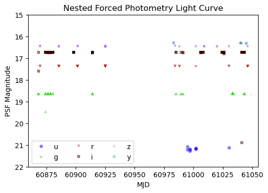

```python
fig = plt.figure(figsize=(6, 4))
for f, filt in enumerate(filter_names):
    tx = (random_object_lc['band'] == filt)
    plt.plot(random_object_lc['midpointMjdTai'][tx], random_object_lc['psfMag'][tx],
             filter_symbols[filt], ms=5, mew=0, alpha=0.5, color=filter_colors[filt], label=filt)
plt.ylim([22, 15])
plt.legend(loc='lower left', ncol=3)
plt.xlabel('MJD')
plt.ylabel('PSF Magnitude')
plt.title('Nested Forced Photometry Light Curve')
plt.show()
```

> **Figure 2:** The forced photometry light curve of a random object in the ECDFS field, extracted from a nested column. This object does not appear to be particularly variable with time.

Clean up.

```python
del object_cat_selected_columns, object_cat_ecdfs, object_cat_mag_range
del random_object, random_object_fs, random_object_df, random_object_lc
```

### 2.2. dia_object_collection

This LSDB-formatted catalog is the same as the DP2 `DiaObject` table, with the `DiaSource` and `ForcedSourceOnDiaObject` records nested per object.

[Column descriptions for the DP2 DiaObject table](https://sdm-schemas.lsst.io/dp2.html#DiaObject).

As with the DP2 `object_collection`, a subset of columns is lazily loaded by default: `dec`, `diaObjectId`, `nDiaSources`, `ra`, and `tract`, plus the nested light-curve columns `diaSource` and `diaObjectForcedSource` (each with a subset of their subcolumns). To load a different set of columns, pass the `columns` argument to `open_catalog`.

```python
dia_object_cat = lsdb.open_catalog(base_path / "dia_object_collection")
```

#### 2.2.1. Access nested light curves

Check which columns are nested.

```python
dia_object_cat.nested_columns
```

```
['diaObjectForcedSource', 'diaSource']
```

The subcolumns in these nested columns are mostly the same as the DP2 `DiaSource` and `ForcedSourceOnDiaObject` tables.

[Column descriptions for the DP2 DiaSource table](https://sdm-schemas.lsst.io/dp2.html#DiaSource).

[Column descriptions for the DP2 ForcedSourceOnDiaObject table](https://sdm-schemas.lsst.io/dp2.html#ForcedSourceOnDiaObject).

There are four additional subcolumns:

- `psfMag` and `psfMagErr` (in both nested columns)
- `scienceMag` and `scienceMagErr` (in the `diaSource` nested column only)

> **Warning:** For both nested columns, the `psfMag` column has been calculated from the `psfFlux` column, but they are not the same: in the `DiaSource` table `psfFlux` is the PSF fit flux in the difference image, but in the `ForcedSourceOnDiaObject` table `psfFlux` is the PSF forced photometry flux in the direct (or science) image. Fluxes measured on a difference image will be negative when the object is brighter in the template image than in the direct (science) image, and so typically, difference-image fluxes are not converted to magnitudes.

Option to display the subcolumns in the nested columns.

```python
# dia_object_cat["diaSource"].dtype.column_dtypes
```

```python
# dia_object_cat["diaObjectForcedSource"].dtype.column_dtypes
```

##### Extract and plot a light curve for a supernova-like transient

The transients detected in DP2 include named, publicly reported events. [AT 2025wab](https://www.wis-tns.org/object/2025wab) is a probable supernova in the ECDFS region, discovered by the [BlackGEM](https://astro.ru.nl/blackgem/) survey on 2025-07-11 (MJD 60867).

Find the DP2 counterpart of AT 2025wab with a small-radius cone search at its TNS-reported coordinates.

```python
ra_at2025wab = 53.311667
dec_at2025wab = -29.588856
transient = dia_object_cat.cone_search(ra=ra_at2025wab, dec=dec_at2025wab, radius_arcsec=2.0)
transient.compute(progress_bar=False)[["diaObjectId", "ra", "dec", "nDiaSources"]]
```

| _healpix_29 | diaObjectId | ra | dec | nDiaSources |
| --- | --- | --- | --- | --- |
| 2528502114738878730 | 753899182879670304 | 53.311638 | -29.588794 | 103 |

1 rows × 4 columns

The cone search returns exactly one DIA object, `diaObjectId` 753899182879670304, with over a hundred difference-image detections spanning both DP2 observing seasons of the ECDFS field.

> **Note:** When the `diaObjectId` is already known, `id_search` (as in Section 2.1.5) is the most efficient way to retrieve it, as it uses the `diaObjectId` index table that is packaged with the collection.

Extract the light curve from the `diaSource` and `diaObjectForcedSource` columns.

```python
transient_ds = transient["diaSource"]
transient_ds_df = transient_ds.compute()
transient_ds_lc = transient_ds_df.iloc[0]

transient_fs = transient['diaObjectForcedSource']
transient_fs_df = transient_fs.compute()
transient_fs_lc = transient_fs_df.iloc[0]
```

Compare light curves that use the forced difference-image flux, the detected difference-image flux, and the detected difference-image flux converted to a magnitude.

This will illustrate why **it is recommended to use forced photometry fluxes for difference-image light curves**.

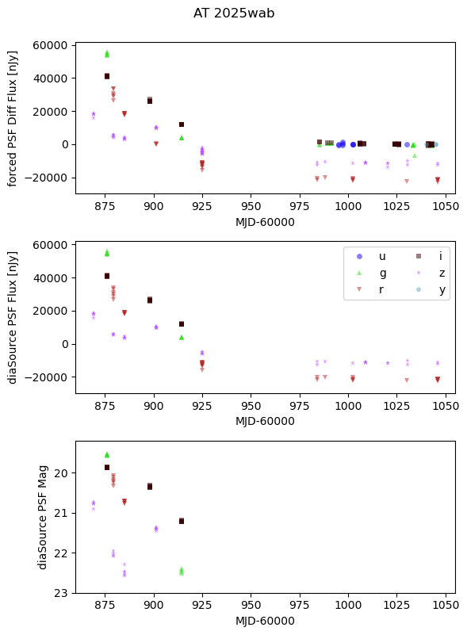

```python
fig, (ax1, ax2, ax3) = plt.subplots(3, 1, figsize=(6, 8))
for f, filt in enumerate(filter_names):
    tx1 = transient_fs_lc["band"] == filt
    tx2 = transient_ds_lc["band"] == filt
    ax1.plot(transient_fs_lc['midpointMjdTai'][tx1]-60000, transient_fs_lc['psfDiffFlux'][tx1],
             filter_symbols[filt], ms=5, mew=0, alpha=0.5, color=filter_colors[filt], label=filt)
    ax2.plot(transient_ds_lc['midpointMjdTai'][tx2]-60000, transient_ds_lc['psfFlux'][tx2],
             filter_symbols[filt], ms=5, mew=0, alpha=0.5, color=filter_colors[filt], label=filt)
    ax3.plot(transient_ds_lc['midpointMjdTai'][tx2]-60000, transient_ds_lc['psfMag'][tx2],
             filter_symbols[filt], ms=5, mew=0, alpha=0.5, color=filter_colors[filt], label=filt)
    del tx1, tx2
ax1.set_xlim([860, 1055])
ax2.set_xlim([860, 1055])
ax3.set_xlim([860, 1055])
ax1.set_ylim([-30000, 62000])
ax2.set_ylim([-30000, 62000])
ax3.set_ylim([23.0, 19.2])
ax1.set_xlabel('MJD-60000')
ax2.set_xlabel('MJD-60000')
ax3.set_xlabel('MJD-60000')
ax1.set_ylabel('forced PSF Diff Flux [nJy]')
ax2.set_ylabel('diaSource PSF Flux [nJy]')
ax3.set_ylabel('diaSource PSF Mag')
ax2.legend(loc='upper right', ncol=2)
plt.suptitle('AT 2025wab', y=0.995)
plt.tight_layout()
plt.show()
```

> **Figure 3:** Top: the forced PSF photometry on the difference image has light curve points from every observation, including the late epochs when the transient had faded. Middle: the `diaSource` PSF-fit photometry only has light curve points when the transient was detected with a signal-to-noise ratio $>$ 5, positive or negative, in the difference image. Note the negative-flux detections at late times, when the transient was dimmer than it appears in the $r$- and $z$-band template images. Bottom: converting difference-image fluxes to magnitudes means the observations where the difference-image flux is negative are lost.

Clean up.

```python
del dia_object_cat, transient
del transient_ds, transient_ds_df, transient_ds_lc
del transient_fs, transient_fs_df, transient_fs_lc
```

### 2.3. object_photoz

This dataset is provided by the Rubin Commissioning Science Unit for photometric redshift.

**Note:** These estimates and their error bars are only very lightly validated. Treat them as provisional and use the results with caution.

The `object_photoz` table contains four point estimate columns per algorithm, following the format: `{pz_algorithm_name}_z_{point_estimate_type}`, where:

- `pz_algorithm_name ∈ ['bpz', 'dnf', 'fzboost', 'gpz', 'knn', 'tpz']`
- `point_estimate_type ∈ ['mode', 'mean', 'median', 'best']`
  - (where eg, `bpz_z_best` would be bpz's recommended point estimate)

The `object_photoz` table also contains 1σ and 2σ credible interval bound columns per algorithm, following a similar format, `{pz_algorithm_name}_z_{interval_bound}`, where:

- `pz_algorithm_name ∈ ['bpz', 'dnf', 'fzboost', 'gpz', 'knn', 'tpz']`
- `interval_bound ∈ ['err68_high', 'err68_low', 'err95_high', 'err95_low']`

In addition, the table provides columns `objectId`, `ra`, and `dec`.

> **Differences from DP1** include the removal of algorithms `cmnn` and `lephare`, the addition of point estimate `zbest`, and the addition of `ra` and `dec` columns.

As mentioned in Section 1, use of the `object_photoz` table is demonstrated in more detail in the 300-level tutorials.

Load the photo-z table.

```python
pz_cat = lsdb.open_catalog(base_path / "object_photoz")
```

Display the results.

```python
pz_cat
```

**lsdb Catalog object_photoz:**

| npartitions=1356 | objectId | ra | dec | bpz_z_best | dnf_z_best | fzboost_z_best | gpz_z_best | knn_z_best | tpz_z_best |
| --- | --- | --- | --- | --- | --- | --- | --- | --- | --- |
| Order: 3, Pixel: 265 | int64[pyarrow] | double[pyarrow] | double[pyarrow] | float[pyarrow] | float[pyarrow] | float[pyarrow] | float[pyarrow] | float[pyarrow] | float[pyarrow] |
| ... | ... | ... | ... | ... | ... | ... | ... | ... | ... |
| Order: 4, Pixel: 3070 | ... | ... | ... | ... | ... | ... | ... | ... | ... |
| Order: 6, Pixel: 49136 | ... | ... | ... | ... | ... | ... | ... | ... | ... |

9 out of 51 available columns in the catalog have been loaded lazily, meaning no data has been read, only the catalog schema

This catalog has an estimated size of 33.7 GB

Clean up.

```python
del pz_cat
```

## 3. Visualize the LSDB sky partitions

LSDB catalogs are divided into **partitions**, which reflect how the LSDB-formatted files are stored. Each partition contains approximately the same number of objects, so partitions are not equal-area regions of the sky. The **HATS partitioning scheme** assigns smaller partitions to dense regions (for example, the Galactic bulge) and larger partitions to sparse regions, ensuring balanced row counts across files.

The `plot_pixels` method of a catalog object visualizes these partitions. The result is not a science-driven sky coverage map but a display of the polygonal partition boundaries. Pixel colors represent pixel sizes, with smaller pixels corresponding to regions of higher source density.

> **Warning:** the following code cell may produce a `UserWarning` about small HEALPix pixels, which is OK to ignore.

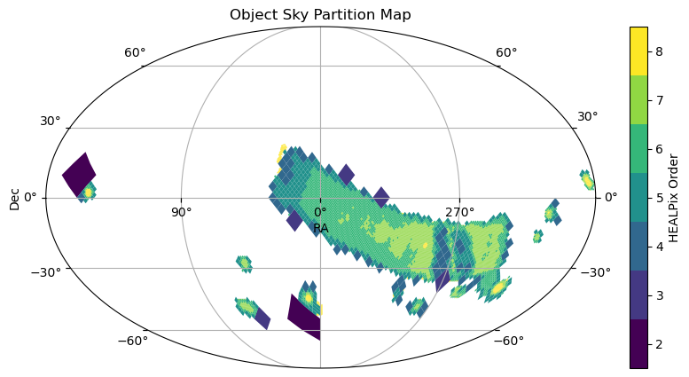

```python
fig = object_cat.plot_pixels(plot_title="Object Sky Partition Map")
```

> **Figure 4:** An all-sky map showing the HEALPix partitions for the LSDB-formatted `object_collection` catalog.

Define a field of view (fov) and center in order to zoom-in on the partitions for the `object_collection` catalog, and re-create the plot.

> **Warning:** The same `UserWarning` will show about small HEALPix pixels.

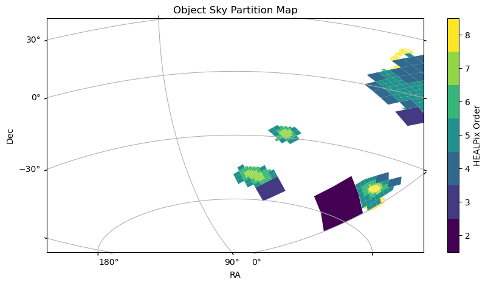

```python
fov = (100 * u.deg, 120 * u.deg)
center = SkyCoord(70 * u.deg, -30 * u.deg)
fig = object_cat.plot_pixels(fov=fov, center=center,
                             plot_title="Object Sky Partition Map")
```

> **Figure 5:** A zoomed-in version of Figure 4.

Clean up.

```python
del object_cat
```

## 4. Learn more about LSDB

As mentioned in Section 1, this notebook is intended only as a simple tutorial on LSDB DP2 catalogs. For more detailed examples and advanced use cases, see [the full set of LSDB tutorials](https://docs.lsdb.io/en/latest/tutorials.html).